**ch0.2 자료형과 연산자**

# **1절 변수**

## **1.1 변수 선언**

- 별도의 변수 선언과정 없음

## **1.2 변수 할당**

- 대입연산자(=) 사용

```
c
#include <stdio.h>
printf()

python
import stdio.h as std
stdio.h.printf() -> std.printf()
```

```python
import numpy as np
print("제공되는 pi값은 ", np.pi)
r = 5
area = np.pi * r* r
# c방식 : printf("계산된 넓이는 %lf", area);
print("계산된 넓이는 ", area)
# python은 변수 선언 안해도 알아서 변수 설정
print("area타입은 ", type(area))
print("area의 주소는 ", id(area))
```

```
제공되는 pi값은  3.141592653589793
계산된 넓이는  78.53981633974483
area타입은  <class 'float'>
area의 주소는  1828224901968
```

```python
area = 10
print("area 값은 ", area)
print("area타입은 ", type(area))
print("area의 주소는 ", id(area))
```

```
area 값은  10
area타입은  <class 'int'>
area의 주소는  140709836342344
```

```python
area = "파이썬은 좋아요"
print("area 값은 ", area)
print("area타입은 ", type(area))
print("area의 주소는 ", id(area))
```

```
area 값은  파이썬은 좋아요
area타입은  <class 'str'>
area의 주소는  1828173983984
```

```
변수 수정하면 다른 주소 할당
할당할 때 변수 type 설정됨
```

## **1.3 변수이름 규칙**

- 문자(특수문자는 _제외하고 안됨), 숫자, _로 명명.
- 문자로 시작
- 파이썬에서 제공되는 기본 함수명은 피하자. 꼭 써야한다면 int_식으로 _를 붙임
- 파이썬 예약어는 변수명 불가 (ex. if)

```python
불용어 = '북한'
불용어
```

```
'북한'
```

```python
print(불용어)
```

```
북한
```

```python
# 파이썬 변수는 함수 할당이 가능
# 하지만 기존의 함수 기능 사용할 수 없게 된다.
print = 5
```

```python
print(불용어)
```

```
---------------------------------------------------------------------------
TypeError                                 Traceback (most recent call last)
Cell In[14], line 1
----> 1 print(불용어)

TypeError: 'int' object is not callable
```

```python
del print # print 변수 삭제
```

```python
print(불용어)
```

```
북한
```

따라서 함수형 언어라고 함 (ex. python, javascript)

```python
# 복소수도 가능
i = 3 + 3j # 복소수
type(i)
```

```
complex
```

```python
a = 10
b = 20
```

```python
a, b = 10, 20 # 다중 선언
```

```python
a, b
```

```
(10, 20)
```

```python
a, b = b, a+b # 다중 선언
print('a=',a, '\t b=',b)
```

```
a= 20 	 b= 30
```

## **1.4 도움말**

```python
help(print)
```

```
Help on built-in function print in module builtins:

print(*args, sep=' ', end='\n', file=None, flush=False)
    Prints the values to a stream, or to sys.stdout by default.

    sep
      string inserted between values, default a space.
    end
      string appended after the last value, default a newline.
    file
      a file-like object (stream); defaults to the current sys.stdout.
    flush
      whether to forcibly flush the stream.
```

```python
print?
```

```
Signature: print(*args, sep=' ', end='\n', file=None, flush=False)
Docstring:
Prints the values to a stream, or to sys.stdout by default.

sep
  string inserted between values, default a space.
end
  string appended after the last value, default a newline.
file
  a file-like object (stream); defaults to the current sys.stdout.
flush
  whether to forcibly flush the stream.
Type:      builtin_function_or_method
```

```python
# 도움말 기능 : 함수 내에서 shift + tab키
print('a', 'b', sep='~')
```

```
a~b
```

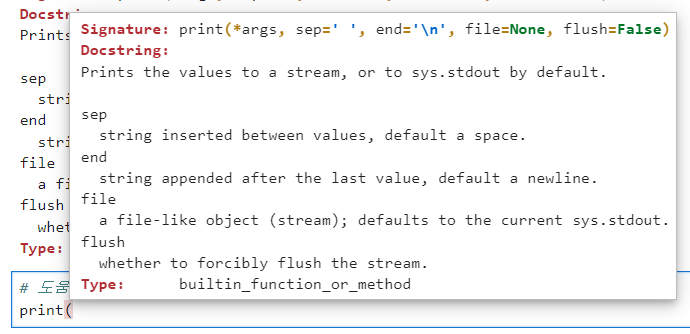

```python
def make_number(x, y=0) :
    """doc string(함수의 도움말)
    매개변수 2개를 이용해서 2자리 정수를 만들기
    x = 10의 자리수
    y = 1의 자리수 (default값 0)
    """
    return x*10 + y
```

ma + **tab키** : 내가 사용할 수 있는 함수 list 나타남

```python
make_number(3, 2)
```

```
32
```

```python
make_number(5) # y의 default값이 0이므로 작성하지 않아도 됨
```

```
50
```

```python
make = make_number # 함수를 변수에 할당
```

```python
make(6)
```

```
60
```

## **1.5 변수 삭제**

```python
del make
```

```python
make(6)
```

```
---------------------------------------------------------------------------
NameError                                 Traceback (most recent call last)
Cell In[36], line 1
----> 1 make(6)

NameError: name 'make' is not defined
```

# **2절 화면 I/O**

```python
# c언어의 scanf
first = input("첫번째 숫자는?") # 문자로 return
second = input("두번째 숫자는?")
```

```python
first, second
```

```
('45', '62')
```

```python
print("두 수의 합은", first+second, "입니다")
print("두 수의 합은 {}".format(first+second)) # 문자 + 문자
```

```
두 수의 합은 4562 입니다
두 수의 합은 4562
```

- 문자로 받지 않고 숫자로 받는 방법

```python
first = int(input("첫번째 숫자는?")) # 숫자로 받기
second = int(input("두번째 숫자는?"))
```

```python
print("두 수의 합은", first+second, "입니다")
print("두 수의 합은 {}".format(first+second)) # 숫자 + 숫자
```

```
두 수의 합은 107 입니다
두 수의 합은 107
```

```python
print("Hello", "world", sep='~')
print("Hello", "Python")
```

```
Hello~world
Hello Python
```

```python
print("Hello", "world", sep='~', end="\t")
print("Hello", "Python")
```

```
Hello~world	Hello Python
```

# **3절 기본 자료형**

- 숫자 : int, float, complex
- 문자 : str
- 논리 : bool

  파이썬은 타입을 지칭하는 키워드가 없고, 변수 할당 시 타입이 정해짐

## **3.1 숫자형**

```python
import sys
print(sys.maxsize) # 모든 크기의 정수를 다 처리 가능
```

```
9223372036854775807
```

```python
a = sys.maxsize + 10
print("값:{} / 주소:{}".format(a, id(a)))
print(type(a))
```

```
값:9223372036854775817 / 주소:1828250647888
<class 'int'>
```

```python
a = 1
print("값: {} / 주소: {}".format(a, id(a)))
print(type(a))
```

```
값: 1 / 주소: 140709836342056
<class 'int'>
```

```python
a = 3/2 # 정수형/정수형 => 실수형(float)
print("값: {} / 주소: {}".format(a, id(a)))
print(type(a))
```

```
값: 1.5 / 주소: 1828173510608
<class 'float'>
```

```python
a = int(3/2) # C언어 결과처럼 하고자 하면 명시적 형변환
a = 3 // 2 # C언어 결과처럼 하고자 하면 몫 연산자
print("값: {} / 주소: {}".format(a, id(a)))
print(type(a))
```

```
값: 1 / 주소: 140709836342056
<class 'int'>
```

```python
f = 1.12e20 # 1.12의 10의 20승
print(f)
f = 1.12e-20 # 1.12의 10의 -20승
print(f)
```

```
1.12e+20
1.12e-20
```

## **3.2 문자형**

```python
name = "홍길동'님'"
print(name)
name = '홍길동"님"'
print(name)
address = "서울시 \"금천구\" \
가산디지털1로"
# \ 다음줄로 계속
print(address)
```

```
홍길동'님'
홍길동"님"
서울시 "금천구" 가산디지털1로
```

```python
text = "안녕하세요.\n홍길동입니다.\n반갑습니다."
print(text)
```

```
안녕하세요.
홍길동입니다.
반갑습니다.
```

```python
text = """안녕하세요.
홍길동입니다.
반갑습니다.
"""
print(text)
```

```
안녕하세요.
홍길동입니다.
반갑습니다.
```

### 문자열 슬라이싱

```python
str_ = "0123456789"
str_
```

```
'0123456789'
```

```python
str_[0]
```

```
'0'
```

```python
str_[0:3] # 0번째부터 3번째 앞까지
```

```
'012'
```

```python
str_[-1] # 음수 인덱스는 뒤에서부터
```

```
'9'
```

```python
str_ = "0123456789"
str_[-5:-1] # 뒤에서부터 5번째부터 뒤에서부터 1번쨰 앞까지
```

```
'5678'
```

```python
str_[-5:] # 5번째 인덱스부터 끝까지
```

```
'56789'
```

```python
str_[:-5] # 처음부터 -5번째 앞까지
```

```
'01234'
```

```python
# str_[19] # 없는 인덱스는 에러남
str_[5:19] # 슬라이싱에서는 인덱스를 벗어나면 끝까지
```

```
'56789'
```

```python
# str_[from:to:step]
print(str_[0:9:2]) # 0번째부터 9번째 앞까지 2씩 인덱스 증가
print(str_[::2]) # 처음부터 끝까지 2씩 인덱스 증가
```

```
02468
02468
```

```python
# 끝부터 처음까지 (거꾸로)
print(str_[9::-1])
print(str_[::-1])
```

```
9876543210
9876543210
```

## **3.3 논리형 (True, False)**

※ 대소문자 유의

```python
a = True
print(a)
print(type(a))
print(isinstance(a, bool)) # a가 bool형이냐?
```

```
True
<class 'bool'>
True
```

```python
# False로 간주하는 것 : 0, None, ""(빈스트링) ''(빈스트링), [], (), {}
# True로 간주하는 것 : 0이 아닌 모든 수, " "(스페이스),'\0'(널문자)
```

```python
if 0+0j:
    print("True")
else:
    print("False")
```

```
False
```

```python
if " ":
    print("True")
else:
    print("False")
```

```
True
```

```python
if []:
    print("True")
else:
    print("False")
```

```
False
```

## **3.4 자료형 확인 및 변환**

- type() : 자료형 확인
- int() : 정수형 변환
- float() : 실수형 변환
- str() : 문자형 변환
- bool() : 논리형 변환

```python
int(" ")
```

```
---------------------------------------------------------------------------
ValueError                                Traceback (most recent call last)
Cell In[104], line 1
----> 1 int(" ")

ValueError: invalid literal for int() with base 10: ' '
```

```python
int("2,000")
```

```
---------------------------------------------------------------------------
ValueError                                Traceback (most recent call last)
Cell In[105], line 1
----> 1 int("2,000")

ValueError: invalid literal for int() with base 10: '2,000'
```

```python
float(True)
```

```
1.0
```

```python
int(True)
```

```
1
```

## **4절 포맷팅**

```python
name = "홍길동"
add = "서울시 금천구"
print("이름은 {}, 주소는 {}".format(name, add))
```

```
이름은 홍길동, 주소는 서울시 금천구
```

```python
name = "홍길동"
add = "서울시 금천구"
print("이름은 {1}, 주소는 {0}".format(name, add))
```

```
이름은 서울시 금천구, 주소는 홍길동
```

```python
name = "홍길동"
add = "서울시 금천구"
print("이름은 {1:10}, 주소는 {0}".format(add, name)) # {1:10} 10칸 확보
```

```
이름은 홍길동       , 주소는 서울시 금천구
```

```python
print("이름은 %s, 주소는 %s"%(name, add))
```

```
이름은 홍길동, 주소는 서울시 금천구
```

```python
print(f"이름은 {name}, 주소는 {add}")
```

```
이름은 홍길동, 주소는 서울시 금천구
```

**format() 함수**

- "{[인덱스]:[공백대체문자][정렬방법][자릿수][타입]}".fortmat(변수명, ...)
- 정렬방법 : <(왼쪽 정렬), >(오른쪽 정렬), ^(가운데 정렬)
- 타입 : d(10진수), x(16진수), b(2진수), f(실수), s(문자)

```python
a = 10
s = "Hello"
print("[{0:$>10d}], [{1:*<20.2}]".format(a, s))
```

```
[$$$$$$$$10], [He******************]
```

# **5절 연산자**

## **5.1 산술연산자 : + - /* //(몫) %(나머지) **(제곱)**

## **5.2 할당연산자 : = += -= /= %= ..**

## **5.3 논리연산자 : & and | or not (연산자 우선순위가 높음)**

## **5.4 비트연산자 : & | ^(OR) (연산자 우선순위가 높음)**

```python
print( (10>3) & (10>5) ) # 논리연산자 True & True
```

```
True
```

```python
print(12 & 1) # 비트연산 12 : 1 1 0 0
              #          1 : 0 0 0 1
print(12 | 1)
```

```
0
13
```

## **5.5 비교연산자 : > >= < <= == !=**

```python
'아' < '하'
```

```
True
```

```python
'*' < '1' < 'A' < 'a' # 코드 순 : 특수문자 < 숫자 < 대문자 < 소문자
```

```
True
```

```python
score = 85
80 <= score and score <90
80 <= score <90 <100
```

```
True
```

# **6절 문자열 다루기**

- 문자열 슬라이싱 : 문자 변수[from:to:step]
- len(문자열) : 문자 개수
- upper() : 대문자로 변환
- lower() : 소문자로 변환
- title() : 각 단어의 앞글자만 대문자로 변환
- capitalize() : 첫문자만 대문자로 변환. 그 외는 소문자
- count('찾을문자열') : 찾을 문자열이 몇 개 들어있는지 개수 반환
- find('찾을문자열') : 찾을 문자열을 왼쪽부터 시작하여 몇 번째 인덱스에 있는지 index 숫자를 반환  
  찾을 문자열이 없으면 -1을 반환
- rfind('찾을문자열') : 찾을 문자열을 오른쪽쪽부터 시작하여 몇 번째 인덱스에 있는지 index 숫자를 반환
- startswith('특정문자열') : 특정 문자열로 시작하는지 여부 T/F 반환
- endswith('특정문자열') : 특정 문자열로 끝나는지 여부 T/F 반환
- strip() : 좌우 공백 제거
- lstrip() : 왼쪽 공백 제거
- rstrip() : 오른쪽 공백 제거
- isdigit() : 문자열이 숫자 문자열인지 여부 T/F 반환
- islower() : 문자열이 소문자인지 여부 T/F 반환
- isuppepr() : 문자열이 대문자인지 여부 T/F 반환
- replace(oldStr, newStr) : oldStr을 newStr로 변경

```python
# 문자열을 다룰 수 있는 함수 목록
dir(str)
```

```
['__add__',
 '__class__',
 '__contains__',
 '__delattr__',
 '__dir__',
 '__doc__',
 '__eq__',
 '__format__',
 '__ge__',
 '__getattribute__',
 '__getitem__',
 '__getnewargs__',
 '__getstate__',
 '__gt__',
 '__hash__',
 '__init__',
 '__init_subclass__',
 '__iter__',
 '__le__',
 '__len__',
 '__lt__',
 '__mod__',
 '__mul__',
 '__ne__',
 '__new__',
 '__reduce__',
 '__reduce_ex__',
 '__repr__',
 '__rmod__',
 '__rmul__',
 '__setattr__',
 '__sizeof__',
 '__str__',
 '__subclasshook__',
 'capitalize',
 'casefold',
 'center',
 'count',
 'encode',
 'endswith',
```

[output cut: 26 more lines]

```
 'rfind',
 'rindex',
 'rjust',
 'rpartition',
 'rsplit',
 'rstrip',
 'split',
 'splitlines',
 'startswith',
 'strip',
 'swapcase',
 'title',
 'translate',
 'upper',
 'zfill']
```

```python
temp = 'Python is easy. Python is smart.'
#       0123567890123456789012345678901
temp.upper(), len(temp)
```

```
('PYTHON IS EASY. PYTHON IS SMART.', 32)
```

```python
print("첫번째 글자 : {}, 마지막 글자 : {}".format(temp[0], temp[-1]))
```

```
첫번째 글자 : P, 마지막 글자 : .
```

```python
temp = 'Python is easy. Python is smart.'
#       0123567890123456789012345678901
print("대문자로 :", temp.upper())
print("첫 글자만 대문자 :",temp.capitalize())
print("title() :", temp.title())
print("count() :", temp.count("Python"))
print("find() :", temp.find("Python"))
print("rfind() :", temp.rfind("Python"))
print("replace('Python', ' ') :", temp.replace("Python", " "))
print("startswith() :", temp.startswith("Py"))
```

```
대문자로 : PYTHON IS EASY. PYTHON IS SMART.
첫 글자만 대문자 : Python is easy. python is smart.
title() : Python Is Easy. Python Is Smart.
count() : 2
find() : 0
rfind() : 16
replace('Python', ' ') :   is easy.   is smart.
startswith() : True
```

```python
temp = "     Python     "
print("원본 : [{}]".format(temp))
print("strip : [{}]".format(temp.strip()))
print("lstrip : [{}]".format(temp.lstrip()))
print("rstrip : [{}]".format(temp.rstrip()))
```

```
원본 : [     Python     ]
strip : [Python]
lstrip : [Python     ]
rstrip : [     Python]
```

```python
temp = "Python is easy Python is smart"
print("space 단위로 분리하여 list로 반환 :", temp.split())
```

```
space 단위로 분리하여 list로 반환 : ['Python', 'is', 'easy', 'Python', 'is', 'smart']
```

```python
type(temp.split())
```

```
list
```

```python
temp = "2024-05-30"
temp_list = temp.split('-')
temp_join = '~'.join(temp_list)
print("년월일 분리 :", temp_list)
print("연결된 temp :", temp_join)
```

```
년월일 분리 : ['2024', '05', '30']
연결된 temp : 2024~05~30
```

# **7절 날짜 다루기**

## **7.1 날짜**

```python
from datetime import date
someday = date(2024, 5, 30)
someday
```

```
datetime.date(2024, 5, 30)
```

```python
print("{:%Y년%m월%d일 %H시 %M분}".format(someday))
```

```
2024년05월30일 00시 00분
```

## **7.2 시간**

```python
from datetime import datetime
now = datetime.today()
print("{:%Y년%m월%d일 %H시 %M분}".format(now))
```

```
2024년05월30일 12시 48분
```

# **8절 연습문제**

1. 사용자로부터 이름과 나이 변수를 입력받아 다음 형식으로 출력하도록 format() 함수를 이용해 형식화하세요.  
   [출력형식 : 홍길동님의 나이는 23살입니다]

```python
name = input("이름을 입력하세요: ")
age = int(input("나이를 입력하세요: "))
print("{}님의 나이는 {}살입니다".format(name, age))
#print("%s님의 나이는 %d살입니다."%(name, age))
#print(f'{name}님의 나이는 {age}살입니다.')
```

```
홍길동님의 나이는 23살입니다
```

2. 두 정수를 입력받아 두 수의 덧셈, 뺄셈, 곱셈, 나눗셈, 몫, 나머지를 출력하세요

```python
int_a = int(input("첫번째 정수를 입력하세요:"))
int_b = int(input("두번째 정수를 입력하세요:"))
print("두 수의 덧셈:{}".format(int_a + int_b))
print("두 수의 뺄셈:{}".format(int_a - int_b))
print("두 수의 곱셈:{}".format(int_a * int_b))
try:
    print("두 수의 나눗셈:{}".format(int_a / int_b))
    print("두 수의 몫:{}".format(int_a // int_b))
    print("두 수의 나머지:{}".format(int_a % int_b))
except:
    print("두 번째 정수에 0을 넣으면 나눌 수 없습니다.")
```

```
두 수의 덧셈:63
두 수의 뺄셈:43
두 수의 곱셈:530
두 수의 나눗셈:5.3
두 수의 몫:5
두 수의 나머지:3
```

3. 문자열의 분리하기와 합치기 기능을 이용하여  
   'Hello World'가 할당된 변수를 이용하여 'World Hello'로 출력하세요.

```python
str = 'Hello World'
str_1 = str[:5]
str_2 = str[6:]
print(str_2 + " " + str_1)

# 정답 참고
splited_str = str.split()
print(splited_str[1], splited_str[0])
```

```
World Hello
World Hello
```

4. x = 'abcedf'를 이용하여 'bcdefa'로 출력하세요 (문자 슬라이싱 이용)

```python
x = 'abcedf'
x[1:] + x[0]
```

```
'bcedfa'
```

5. x = 'abcdef'를 이용하여 'fdecba'로 출력하세요

```python
x = 'abcedf'
x[::-1]
```

```
'fdecba'
```

6. 오늘의 온도를 섭씨온도로 입력받아 화씨 온도로 변환하는 프로그램을 작성하세요.

화씨 온도는 소수점이 있을 경우만 두번째 자리까지 출력되고,  
소수점이하 값이 없는 경우 소수점을 출력하지 않도록 합니다.  
(다음은 섭씨와 화씨의 변환 공식입니다. C는 섭씨, F는 화씨)  
C = (F-32) / 1.8  
F = (C*1.8) + 32

```python
# 답안 풀이 참고
c = int(input("섭씨온도를 입력하세요:"))
f = (c*1.8) + 32
if f == round(f):
    print("섭씨 {}도는 화씨온도로 바꾸면 {:.0f}도입니다.".format(c, f))
else:
    print("섭씨 {}도는 화씨온도로 바꾸면 {:.2f}도입니다.".format(c, f))

# {:.소수점 자리수f} 포맷 코드
# {} 내에 실수의 소수점 자리수(.소수점 자리수f)를 지정해 줄 수 있음
```

```
섭씨 26도는 화씨온도로 바꾸면 78.80도입니다.
```

7. 다음 중 변수 선언으로 잘못된 것은?
   1. for
   2. 10th
   3. Student.name
   4. _1234

답: 1,2,3 1) 함수 이름 사용X 2) 숫자 시작X 3) . 포함되면 X

8. 다음의 코드를 실행하면?

```python
text = "Seoul A001 - programming with python"
print(text[:4] + text[-1] + text.split()[0])
print(text[:4], text[-1], text.split()[0])
```

```
SeounSeoul
Seou n Seoul
```

9. 다음 중 파이썬 3.x 버전에서 연산식과 그 결과의 출력이 잘못된 것은?
   1. 수식 8//2 결과 4
   2. 수식 8/2 결과 4
   3. 수식 8**2 결과 64

```python
8//2
```

```
4
```

```python
8/2
```

```
4.0
```

```python
8**2
```

```
64
```

답: B 결과는 4가 아닌 4.0